# Introduction to R

Jacob Simmering

Nov 1st, 2017

# Setup

You will need to have a version of R installed. It can be downloaded for your system at [CRAN](https://cran.r-project.org/). Also you will want to install the `tidyverse` inside R. You can do this by running `install.packages("tidyverse")` in an R session. Finally, while not required, the [RStudio IDE](https://www.rstudio.com/) will make your R sessions much easier to manage.

# Overview

## The R Langague

I am not going to spend a lot of time R as a language. I’ll cover some syntax as we reach it. I’ll cover just a few brief terms and conventions here.

*Packages* are contributed extensions to the R language to enable specific tasks or analyses. If you are familiar with Python, these are like libraries or gems in Ruby. Most of the time, there is a contributed version on CRAN that you can easily install with `install.packages("<package name>")` in your R session. It will download and install the requested package as well as any dependencies required. Once a package is installed, you can load it into your session with `library(<package name>)`. Quotes are required to install but optional when loading the library.

The `<-` (read as “gets”) is the primary assignment operator in R. If you want to set the value of `x` to `1`, you would run `x <- 1`. This is directional, so `1 -> x` is also valid (useful if you just typed a long line and forgot to assign it, but probably not good practice!). You can use `=` for assignment (and indeed need to when you are passing function arguments) but for whatever reason that is not standard practice.

The operator `%>%` is added when you load the `tidyverse` package and is known as the “pipe” operator. You can understand read this as “then”. This is used to string together a series of operations into one group while splitting across lines for readability and avoiding nesting of parenthesis. We’ll discuss this later in context.

There are three atomic data types in R.

- “numeric” - this stores floating point and integer values. Typically, it will store the value as a double precision floating point but integer can be forced if desired.
- “factor” - this looks like a string but it isn’t! Factors are categorical variables with discrete levels (e.g., male vs female, dog vs cat vs mouse). In R, they are actually stored internally as a series of integers and R converts these integers to labels (e.g., 1 = male, 2 = female) when it shows output. This can be confusing because they look like strings but aren’t - it makes sense in R’s standard statistical use-case but will almost certainly make everyone groan at least once.
- “character” - this is actually the string-type in R. Most of the tools I’ll discuss today don’t convert characters to factors but historically R has coerced characters into factors when reading data into a session.

There are a set of higher level data types in R:

- “vector” - a vector is 1-D collection of values, all of the same data type. A “vector” in R and a “vector” in math mean approximately the same thing. For instance `c(1, 2, 3)` is a vector as is `c("A", "B", "C")` (`c()` is the function used to construct a vector, `c` standards for “combine” or “concatenation”). R will automatically convert a vector with mixed types into the most strict atomic data type that can hold all of the values in the vector. For instance, `c(1, 2, "A")` will become a string of character values.
- “matrix” - a matrix is a 2-D collection of values. This is the same as a “matrix” in math. Like a vector, it can only hold one atomic data type.
- “array” - an array is a generalization of a matrix to any number of dimensions. This can be useful to hold data where you have clear “slices” (e.g., intensity by x and y at several difference values of t). Again, this can only hold one atomic data type.
- “data.frame” - a data.frame is the primary data storage object in base R. It is a collection of vectors, each displayed as a column, and is analogous to a table or spreadsheet. The columns can be of different types.
- “tibble” - a tibble (a corruption of the word “table” which was abbreviated as “tbl” in the output) is an extension of the data.frame provided by the `tibble` package in the `tidyverse`. The main advantages of a tibble are a better print method and it makes it a little harder to get yourself in trouble. For more on tibbles see [R for Data Science Chapter 10](http://r4ds.had.co.nz/tibbles.html).
- “list” - a list is a collection of any R data types with each element being potentially a different type. These come in handy when doing functional programming tasks.

I am going to be mostly using tibble type objects here. We will touch briefly on lists towards the end if time permits. I’ll mention vectors in a few places as they will be used next week.

## The Packages We’ll Use Today

I am going to cover using R, mostly focusing on data importation, manipulation and visualization. I’ll also cover the different data types in R, extensions of these data types and, time permitting, some functional programming in R. Next week Aaron Miller will cover machine learning in R.

Most of the examples in this book will use a package called `tidyverse`. The tidyverse is a collection of tools to help with the data importation and manipulation challenges in R. Specifically, we will discuss the following packages this week

- `dplyr`
- `ggplot2`
- `tidyr`
- `readr`
- `stringr`
- `purrr`
- `broom`

## The Data We’ll Use Today

We will be using the data sets in the `nycflights13` package. However, instead of using the package we are going to read in the data directly. We’ll discuss reading in the data next, but first a brief overview of the data. The data is a summary of the on-time data for all flights that left NYC in 2013 and includes “metadata” such as airline, airport the plane was flying to, weather and the plane. The data was collected and compiled into the R package by Hadley Wickham in 2017.

There are five tables. They are

- airlines
- airports
- flights
- planes
- weather

A sample schema showing how they are joined (taken from R4DS)

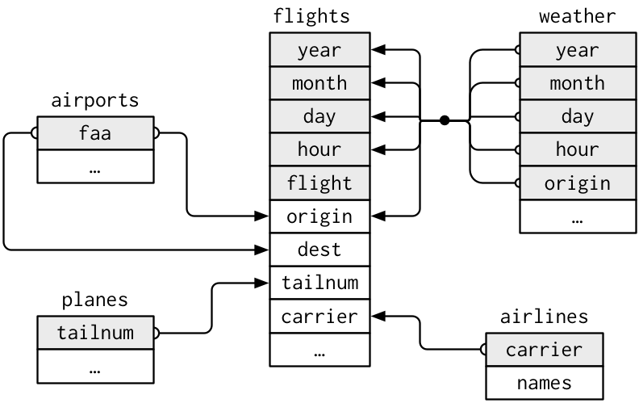

Schema for Flights Data

# Data Science Workflow

The tidyverse suggests a workflow of data exploration and analysis depicted in the figure below (taken from R for Data Science)

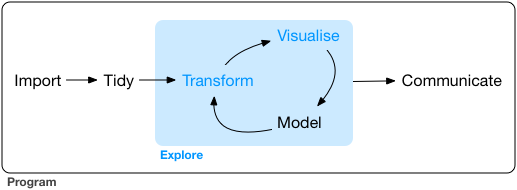

Idealized Data Science Workflow

The ideal is that you import your (potentially unstructured/messy) data, tidy it (convert it into a cleaned, rectangular format, more on tidy data later) and then enter the analysis/exploration cycle. Here you start by transforming your data, visualizing relationships, modeling those relationships and then potentially returning to the transformation and repeating the process. Once you have finalized the model/completed the analysis, you communicate your results.

The tidyverse package has a number of child packages that cover these tasks more-or-less in a 1:1 fashion:

- `readr` covers many forms of data import into R
- `tidyr` assists with tidying messy data and getting it into the desired format
- `dplyr` covers many, if not most, transformations of the data you might want to do
- `ggplot2` is a powerful and visually appealing tool for producing visualizations of your data and any relationships within
- `modelr`, `purrr` and the base R functions `lm()` and `glm()` form the bulk of the modeling stage
- `knitr` provides an easy way to embedded R code and results inside Markdown files for easy drafting of reports and communication

I will briefly cover the use of `readr` and `tidyr` today. I will cover `dplyr` in-depth and provide an introduction to `ggplot2`. There won’t be time to cover the regression and model methods in much detail without getting bogged down in the stats

# Data Import

For more information see [Chapter 11 of R for Data Science](http://r4ds.had.co.nz/data-import.html)

Start a new R script in RStudio and add the following to the top of the script

```r
library(tidyverse)
```

And run the line (click on the “Run” icon or put your cursor on the line and press crtl-enter (Windows, Linux) or cmd-enter (OS X)). This should send your code to the console to execute.

If you see the message `Error in library(tidyverse) : there is no package called 'tidyverse'` it means that the `tidyverse` package is not installed. In the console, run `install.packages("tidyverse")` to install it and then re-run the line.

If you see the following:

```
Loading tidyverse: ggplot2
Loading tidyverse: tibble
Loading tidyverse: tidyr
Loading tidyverse: readr
Loading tidyverse: purrr
Loading tidyverse: dplyr
Conflicts with tidy packages ---------------------------------------------------
filter(): dplyr, stats
lag():    dplyr, stats
```

It means that you have successfully loaded the `tidyverse` and related packages into your R session. The `Conflicts with tidy packages` section lists places where there are two functions with the same name being loaded into the global namespace. By default, the last function loaded will be the default. For instance, if I run the function `lag()` it will use the `lag()` as defined by the `dplyr` package since I loaded that after the `stats` package was loaded. If I want to access the `stats` version of `lag()`, I can explicitly identify the namespace using the format `namespace::function()` or `stats::lag()` in this case.

We are going to use the `readr` package to load our data. There are specialized functions in the `readr` package to read tab-separated files, fixed-with files, delimited files and comma-separated files. We are going to focus on csv’s, but you can read in pretty much any plain-text file with `readr`.

The main function we want to use is `read_csv()`. If you enter `?read_csv` in the console, you should be able to see the Help package for the `read_csv()` function. You’ll see the description that: “read_csv() and read_tsv() are special cases of the general read_delim(). They’re useful for reading the most common types of flat file data, comma separated values and tab separated values, respectively. read_csv2() uses ; for separators, instead of ,. This is common in European countries which use , as the decimal separator.” Looking under the Usage entry, we see

```
read_csv(file, col_names = TRUE, col_types = NULL,
  locale = default_locale(), na = c("", "NA"), quoted_na = TRUE,
  quote = "\"", comment = "", trim_ws = TRUE, skip = 0, n_max = Inf,
  guess_max = min(1000, n_max), progress = show_progress())
```

That is a lot of arguments to manage and the arguments section goes through them in detail. We won’t need to change many of these from defaults. In general, you only need to worry about setting `file` and, occasionally, `col_types`.

I’ve provided all of the data we are going to use in the `data` directory of this repo. Let’s one of the files and print it:

```r
airlines <- read_csv("data/airlines.csv")
airlines
```

```
## # A tibble: 16 x 2
##    carrier                        name
##      <chr>                       <chr>
##  1      9E           Endeavor Air Inc.
##  2      AA      American Airlines Inc.
##  3      AS        Alaska Airlines Inc.
##  4      B6             JetBlue Airways
##  5      DL        Delta Air Lines Inc.
##  6      EV    ExpressJet Airlines Inc.
##  7      F9      Frontier Airlines Inc.
##  8      FL AirTran Airways Corporation
##  9      HA      Hawaiian Airlines Inc.
## 10      MQ                   Envoy Air
## 11      OO       SkyWest Airlines Inc.
## 12      UA       United Air Lines Inc.
## 13      US             US Airways Inc.
## 14      VX              Virgin America
## 15      WN      Southwest Airlines Co.
## 16      YV          Mesa Airlines Inc.
```

When we print out the object, we see that it is a tibble with 2 columns and 16 rows. `carrier` appears to be a short 2-letter abbreviation for an airline and `name` is the full name of the airline company.

We can do this with the rest of the files as well:

```r
airports <- read_csv("data/airports.csv")
planes <- read_csv("data/planes.csv")
flights <- read_csv("data/flights.csv")
weather <- read_csv("data/weather.csv")
```

The other data import functions in `readr` will produce similar results.

# Data Manipulation

## A Note on Tidy Data

I’m going to take a brief minute here to discuss “tidy” data. The idea behind tidy data is similar to normalization in databases and indeed tidy data can be thought of as a re-casting of 3rd Normal Form in a statistical language. Specifically,

1. Each variable must have its own column;
2. Each observation must have its own row;
3. Each value must have its own cell.

If the data is stored as such, it makes manipulating it and producing summaries, aggregations and other data transformations easier. It also means the data is stored consistently and do you don’t have to re-learn the data structure every project.

The tools in the tidyverse are designed around the idea of tidy data and integrate neatly with the concept. If you have tidy data, use of these tools will feel natural and intuitive.

All of the data sets that we have are tidy, but if they aren’t (or you just need to do it) the functions `gather()` and `spread()` from the `tidyr` package (part of the tidyverse) are useful. `gather()` takes “wide” data and makes it long. For instance,

```r
stocks <- tibble(
  time = as.Date('2009-01-01') + 0:9,
  X = rnorm(10, 0, 1), # just generates some random numbers
  Y = rnorm(10, 0, 2), # just generates some random numbers
  Z = rnorm(10, 0, 4) # just generates some random numbers
)
stocks
```

```
## # A tibble: 10 x 4
##          time          X          Y          Z
##        <date>      <dbl>      <dbl>      <dbl>
##  1 2009-01-01 -0.2318792 -1.6255179 -0.6203246
##  2 2009-01-02 -1.1990562 -0.9824760 -0.4397476
##  3 2009-01-03 -3.0165659  0.4779851  6.1688874
##  4 2009-01-04  0.3180617  2.5289219 -4.5976719
##  5 2009-01-05 -0.2068513  0.5374342 -4.4933247
##  6 2009-01-06 -0.7756782 -0.0622488  2.2114456
##  7 2009-01-07  0.7408788  5.5246039 -0.9313280
##  8 2009-01-08 -0.5918666  1.5372037 -7.4794175
##  9 2009-01-09 -0.4918802  1.1607752  3.6869826
## 10 2009-01-10 -0.7043410 -3.1264824 -0.5016646
```

is the closing price of 3 stocks “X”, “Y” and “Z” at the end of each day from 2009-1-1 to 2009-1-10. If we wanted them to be long such that there was 3 rows for each time, a column that indicates the stock and a column that indicates the closing price, we would use `gather()`. `gather()` typically takes 4 arguments: `data` is the name of the tibble to perform the operation on, `key` is the name to use for the column that will become the key, `value` is the name to use for the column that will hold the value then a comma separated list of variables to include (or prefix with a `-` sign to exclude). For the `stocks` example

```r
stocks_wide <- gather(stocks, stock, closing_price, -time)
stocks_wide
```

```
## # A tibble: 30 x 3
##          time stock closing_price
##        <date> <chr>         <dbl>
##  1 2009-01-01     X    -0.2318792
##  2 2009-01-02     X    -1.1990562
##  3 2009-01-03     X    -3.0165659
##  4 2009-01-04     X     0.3180617
##  5 2009-01-05     X    -0.2068513
##  6 2009-01-06     X    -0.7756782
##  7 2009-01-07     X     0.7408788
##  8 2009-01-08     X    -0.5918666
##  9 2009-01-09     X    -0.4918802
## 10 2009-01-10     X    -0.7043410
## # ... with 20 more rows
```

and we can convert back to wide using `spread()`. This reverses the action of `gather()`. The first argument should be the name of the tibble to act on (in this case `stocks_wide`), the second should be the name of the column that contains the values to use as the new column names (`stocks`) and the third should contain the values used to fill the new cells (`closing_price`).

```r
spread(stocks_wide, stock, closing_price)
```

```
## # A tibble: 10 x 4
##          time          X          Y          Z
##  *     <date>      <dbl>      <dbl>      <dbl>
##  1 2009-01-01 -0.2318792 -1.6255179 -0.6203246
##  2 2009-01-02 -1.1990562 -0.9824760 -0.4397476
##  3 2009-01-03 -3.0165659  0.4779851  6.1688874
##  4 2009-01-04  0.3180617  2.5289219 -4.5976719
##  5 2009-01-05 -0.2068513  0.5374342 -4.4933247
##  6 2009-01-06 -0.7756782 -0.0622488  2.2114456
##  7 2009-01-07  0.7408788  5.5246039 -0.9313280
##  8 2009-01-08 -0.5918666  1.5372037 -7.4794175
##  9 2009-01-09 -0.4918802  1.1607752  3.6869826
## 10 2009-01-10 -0.7043410 -3.1264824 -0.5016646
```

These are handy little tools to keep in your tool kit. Moving from wide-to-long happens more than you’d expect.

For more on tidy data, its importance and how it works influences the `tidyverse` see [R for Data Science Chapter 12](http://r4ds.had.co.nz/tidy-data.html).

## The `dplyr` Verbs

`dplyr` is a workhorse package to manipulating and summarizing data. The most exciting thing about `dplyr` is that the syntax and code is the same for working on an in-memory dataset (like we do here) or a SQL database. `dbplyr` is a package that extends `dplyr` and converts your R code into SQL queries and passes them off to the RDBMS. This is really cool when you are working with large data sets and makes the transition between in-memory data manipulation and on-disk data manipulation seamless. It is also very easy to use, which doesn’t hurt at all!

In general, `dplyr` is simply a collection of six verbs (or five verbs and one adverb) which will do about 99% of all data manipulation tasks you might want to do. The verbs are

- `select()`
- `filter()`
- `mutate()`
- `summarize()`
- `arrange()`
- `group_by()` (this might actually be an adverb)

We’ll go through what each function does and how to use it using the `nycflights13` data sets as an example.

### `select()`

Select does what it says - it selects things. You give it the name of a data object and then a comma separated list of variables and it returns the data object with only those variables.

Let’s start with the `airports` table

```r
airports
```

```
## # A tibble: 1,458 x 8
##      faa                           name      lat        lon   alt    tz
##    <chr>                          <chr>    <dbl>      <dbl> <int> <int>
##  1   04G              Lansdowne Airport 41.13047  -80.61958  1044    -5
##  2   06A  Moton Field Municipal Airport 32.46057  -85.68003   264    -6
##  3   06C            Schaumburg Regional 41.98934  -88.10124   801    -6
##  4   06N                Randall Airport 41.43191  -74.39156   523    -5
##  5   09J          Jekyll Island Airport 31.07447  -81.42778    11    -5
##  6   0A9 Elizabethton Municipal Airport 36.37122  -82.17342  1593    -5
##  7   0G6        Williams County Airport 41.46731  -84.50678   730    -5
##  8   0G7  Finger Lakes Regional Airport 42.88356  -76.78123   492    -5
##  9   0P2   Shoestring Aviation Airfield 39.79482  -76.64719  1000    -5
## 10   0S9          Jefferson County Intl 48.05381 -122.81064   108    -8
## # ... with 1,448 more rows, and 2 more variables: dst <chr>, tzone <chr>
```

```r
select(airports, faa, lat, lon)
```

```
## # A tibble: 1,458 x 3
##      faa      lat        lon
##    <chr>    <dbl>      <dbl>
##  1   04G 41.13047  -80.61958
##  2   06A 32.46057  -85.68003
##  3   06C 41.98934  -88.10124
##  4   06N 41.43191  -74.39156
##  5   09J 31.07447  -81.42778
##  6   0A9 36.37122  -82.17342
##  7   0G6 41.46731  -84.50678
##  8   0G7 42.88356  -76.78123
##  9   0P2 39.79482  -76.64719
## 10   0S9 48.05381 -122.81064
## # ... with 1,448 more rows
```

We can also exclude specific variables by putting a `-` in front of the variable name

```r
select(airports, -faa)
```

```
## # A tibble: 1,458 x 7
##                              name      lat        lon   alt    tz   dst
##                             <chr>    <dbl>      <dbl> <int> <int> <chr>
##  1              Lansdowne Airport 41.13047  -80.61958  1044    -5     A
##  2  Moton Field Municipal Airport 32.46057  -85.68003   264    -6     A
##  3            Schaumburg Regional 41.98934  -88.10124   801    -6     A
##  4                Randall Airport 41.43191  -74.39156   523    -5     A
##  5          Jekyll Island Airport 31.07447  -81.42778    11    -5     A
##  6 Elizabethton Municipal Airport 36.37122  -82.17342  1593    -5     A
##  7        Williams County Airport 41.46731  -84.50678   730    -5     A
##  8  Finger Lakes Regional Airport 42.88356  -76.78123   492    -5     A
##  9   Shoestring Aviation Airfield 39.79482  -76.64719  1000    -5     U
## 10          Jefferson County Intl 48.05381 -122.81064   108    -8     A
## # ... with 1,448 more rows, and 1 more variables: tzone <chr>
```

We can also use a set of helper functions to select the desired variables:

- `starts_with(match)` - returns any variables that start with the value passed as `match`
- `ends_with(match)` - returns any variables that ends with the value passed as `match`
- `contains(match)` - returns any variables that contain the value `match`

#### Exercises

1. Arrange the data by the distance covered by the flight

### `filter()`

`filter()` filters things. It takes as a first argument the name of the data object (a tibble or data.frame) to filter and then a series of comma separated expressions that evaluate to logical TRUE/FALSE statements about a given row.

The `flights` table is a good place to try this:

```r
flights
```

```
## # A tibble: 336,776 x 19
##     year month   day dep_time sched_dep_time dep_delay arr_time
##    <int> <int> <int>    <int>          <int>     <int>    <int>
##  1  2013     1     1      517            515         2      830
##  2  2013     1     1      533            529         4      850
##  3  2013     1     1      542            540         2      923
##  4  2013     1     1      544            545        -1     1004
##  5  2013     1     1      554            600        -6      812
##  6  2013     1     1      554            558        -4      740
##  7  2013     1     1      555            600        -5      913
##  8  2013     1     1      557            600        -3      709
##  9  2013     1     1      557            600        -3      838
## 10  2013     1     1      558            600        -2      753
## # ... with 336,766 more rows, and 12 more variables: sched_arr_time <int>,
## #   arr_delay <int>, carrier <chr>, flight <int>, tailnum <chr>,
## #   origin <chr>, dest <chr>, air_time <int>, distance <int>, hour <int>,
## #   minute <int>, time_hour <dttm>
```

Suppose we wanted to find it any flight from NYC went to Des Moines airport in 2013. The expression would test if `dest == "DSM"`. So

```r
filter(flights, dest == "DSM")
```

```
## # A tibble: 569 x 19
##     year month   day dep_time sched_dep_time dep_delay arr_time
##    <int> <int> <int>    <int>          <int>     <int>    <int>
##  1  2013     1     1     2119           1930       109     2358
##  2  2013     1     2     1921           1909        12     2143
##  3  2013     1     3     1938           1905        33     2136
##  4  2013     1     4     1907           1905         2     2108
##  5  2013     1     6     1904           1910        -6     2111
##  6  2013     1     7     1903           1905        -2     2059
##  7  2013     1     8     1901           1905        -4     2119
##  8  2013     1     9     2006           1905        61     2231
##  9  2013     1    10     1858           1905        -7     2059
## 10  2013     1    11     1858           1905        -7     2125
## # ... with 559 more rows, and 12 more variables: sched_arr_time <int>,
## #   arr_delay <int>, carrier <chr>, flight <int>, tailnum <chr>,
## #   origin <chr>, dest <chr>, air_time <int>, distance <int>, hour <int>,
## #   minute <int>, time_hour <dttm>
```

Suppose we wanted multiple filtering rules, we can string them together with commas and `filter()` understands that as “AND”. So `filter(data, x, y)` means return rows in data where both x AND y are true.

```r
filter(flights, year == 2013, month == 1, day == 1)
```

```
## # A tibble: 842 x 19
##     year month   day dep_time sched_dep_time dep_delay arr_time
##    <int> <int> <int>    <int>          <int>     <int>    <int>
##  1  2013     1     1      517            515         2      830
##  2  2013     1     1      533            529         4      850
##  3  2013     1     1      542            540         2      923
##  4  2013     1     1      544            545        -1     1004
##  5  2013     1     1      554            600        -6      812
##  6  2013     1     1      554            558        -4      740
##  7  2013     1     1      555            600        -5      913
##  8  2013     1     1      557            600        -3      709
##  9  2013     1     1      557            600        -3      838
## 10  2013     1     1      558            600        -2      753
## # ... with 832 more rows, and 12 more variables: sched_arr_time <int>,
## #   arr_delay <int>, carrier <chr>, flight <int>, tailnum <chr>,
## #   origin <chr>, dest <chr>, air_time <int>, distance <int>, hour <int>,
## #   minute <int>, time_hour <dttm>
```

You can join using “OR” as well. In R, the logical operator OR is expressed as `|`. For instance, if I want to find flights that left either more than 5 minutes before or 5 minutes after their scheduled time, I would run

```r
filter(flights, (dep_time - sched_dep_time) >= 5 | (dep_time - sched_dep_time) <= -5)
```

```
## # A tibble: 217,411 x 19
##     year month   day dep_time sched_dep_time dep_delay arr_time
##    <int> <int> <int>    <int>          <int>     <int>    <int>
##  1  2013     1     1      554            600        -6      812
##  2  2013     1     1      555            600        -5      913
##  3  2013     1     1      557            600        -3      709
##  4  2013     1     1      557            600        -3      838
##  5  2013     1     1      558            600        -2      753
##  6  2013     1     1      558            600        -2      849
##  7  2013     1     1      558            600        -2      853
##  8  2013     1     1      558            600        -2      924
##  9  2013     1     1      558            600        -2      923
## 10  2013     1     1      559            600        -1      941
## # ... with 217,401 more rows, and 12 more variables: sched_arr_time <int>,
## #   arr_delay <int>, carrier <chr>, flight <int>, tailnum <chr>,
## #   origin <chr>, dest <chr>, air_time <int>, distance <int>, hour <int>,
## #   minute <int>, time_hour <dttm>
```

which differs from separating with a comma

```r
filter(flights, (dep_time - sched_dep_time) >= 5, (dep_time - sched_dep_time) <= -5)
```

```
## # A tibble: 0 x 19
## # ... with 19 variables: year <int>, month <int>, day <int>,
## #   dep_time <int>, sched_dep_time <int>, dep_delay <int>, arr_time <int>,
## #   sched_arr_time <int>, arr_delay <int>, carrier <chr>, flight <int>,
## #   tailnum <chr>, origin <chr>, dest <chr>, air_time <int>,
## #   distance <int>, hour <int>, minute <int>, time_hour <dttm>
```

which returns zero rows (no flight can leave both 5 minutes before and 5 minutes after the scheduled time).

Filter also works to when using functions in the logical statement. We could find the longest distance flight on May 27th using

```r
filter(flights, month == 5, day == 27, distance == max(distance, na.rm = TRUE))
```

```
## # A tibble: 1 x 19
##    year month   day dep_time sched_dep_time dep_delay arr_time
##   <int> <int> <int>    <int>          <int>     <int>    <int>
## 1  2013     5    27      958           1000        -2     1420
## # ... with 12 more variables: sched_arr_time <int>, arr_delay <int>,
## #   carrier <chr>, flight <int>, tailnum <chr>, origin <chr>, dest <chr>,
## #   air_time <int>, distance <int>, hour <int>, minute <int>,
## #   time_hour <dttm>
```

#### Exercises

From R for Data Science Chapter 5

Find all flights that:

1. Arrived 2 or more hours late
2. Flew to DSM or OMA
3. Operated by UA, AA or DL
4. Arrived more than 2 hours late but didn’t leave late
5. Delayed in leaving by at least 1 hour but made up 30 hours in flight

### `mutate()`

`mutate` is used to add new variables to a tibble. As with the other verbs so far, the first argument is the name of the tibble to mutate followed by a comma separated list of variables and the values to assign to those variables. The assignment is done in the form `variable_name = value`.

The `flights` table contains information about the flight time and distance but does not include the speed. We could combine the air time and the distance to estimate speed. Let’s do that:

```r
flights <- mutate(flights, speed = distance / (air_time / 60))
```

And now if we view flights, we’ll see a new variable called speed:

```r
select(flights, distance, air_time, speed)
```

```
## # A tibble: 336,776 x 3
##    distance air_time    speed
##       <int>    <int>    <dbl>
##  1     1400      227 370.0441
##  2     1416      227 374.2731
##  3     1089      160 408.3750
##  4     1576      183 516.7213
##  5      762      116 394.1379
##  6      719      150 287.6000
##  7     1065      158 404.4304
##  8      229       53 259.2453
##  9      944      140 404.5714
## 10      733      138 318.6957
## # ... with 336,766 more rows
```

Multiple variables can be constructed inside a single `mutate()` call:

```r
flights <- mutate(flights,
       dep_delay = dep_time - sched_dep_time,
       arr_delay = arr_time - sched_arr_time)
select(flights, dep_delay, arr_delay)
```

```
## # A tibble: 336,776 x 2
##    dep_delay arr_delay
##        <int>     <int>
##  1         2        11
##  2         4        20
##  3         2        73
##  4        -1       -18
##  5       -46       -25
##  6        -4        12
##  7       -45        59
##  8       -43       -14
##  9       -43        -8
## 10       -42         8
## # ... with 336,766 more rows
```

### `summarize()`

`summarize()` takes as the first argument, you guessed it, the data object and the following arguments are in the same manner as with mutate. While `mutate()` must returns an $n$ row column, `summarize()` must return a 1 row column that is a summary measure (e.g., mean, sd, median). If we wanted to get an idea of the mean and standard deviation of the arrival delays, we would use

```r
# na.rm = TRUE just means ignore rows where there is a missing value
summarize(flights,
          mean_arrival_delay = mean(arr_delay, na.rm = TRUE),
          sd_arrival_delay = sd(arr_delay, na.rm = TRUE))
```

```
## # A tibble: 1 x 2
##   mean_arrival_delay sd_arrival_delay
##                <dbl>            <dbl>
## 1          -30.85636         336.6009
```

### `arrange()`

`arrange()` is used to order data by a variable in the data. For instance, if we wanted to order the `flights` table by the the departure time, we would run

```r
arrange(flights, dep_time)
```

```
## # A tibble: 336,776 x 20
##     year month   day dep_time sched_dep_time dep_delay arr_time
##    <int> <int> <int>    <int>          <int>     <int>    <int>
##  1  2013     1    13        1           2249     -2248      108
##  2  2013     1    31        1           2100     -2099      124
##  3  2013    11    13        1           2359     -2358      442
##  4  2013    12    16        1           2359     -2358      447
##  5  2013    12    20        1           2359     -2358      430
##  6  2013    12    26        1           2359     -2358      437
##  7  2013    12    30        1           2359     -2358      441
##  8  2013     2    11        1           2100     -2099      111
##  9  2013     2    24        1           2245     -2244      121
## 10  2013     3     8        1           2355     -2354      431
## # ... with 336,766 more rows, and 13 more variables: sched_arr_time <int>,
## #   arr_delay <int>, carrier <chr>, flight <int>, tailnum <chr>,
## #   origin <chr>, dest <chr>, air_time <int>, distance <int>, hour <int>,
## #   minute <int>, time_hour <dttm>, speed <dbl>
```

and we get a bunch of flights that left at 00:01.

### `group_by()`

The major value of `dplyr` comes with the `group_by` function when combined with the prior verbs. `group_by` modifies the prior verbs so that they operate on a group basis. For instance, if we wanted the mean arrival delay by airline,

```r
flights <- group_by(flights, carrier)
```

You’ll notice that `flights` doesn’t look much different if you print it

```r
flights
```

```
## # A tibble: 336,776 x 20
## # Groups:   carrier [16]
##     year month   day dep_time sched_dep_time dep_delay arr_time
##    <int> <int> <int>    <int>          <int>     <int>    <int>
##  1  2013     1     1      517            515         2      830
##  2  2013     1     1      533            529         4      850
##  3  2013     1     1      542            540         2      923
##  4  2013     1     1      544            545        -1     1004
##  5  2013     1     1      554            600       -46      812
##  6  2013     1     1      554            558        -4      740
##  7  2013     1     1      555            600       -45      913
##  8  2013     1     1      557            600       -43      709
##  9  2013     1     1      557            600       -43      838
## 10  2013     1     1      558            600       -42      753
## # ... with 336,766 more rows, and 13 more variables: sched_arr_time <int>,
## #   arr_delay <int>, carrier <chr>, flight <int>, tailnum <chr>,
## #   origin <chr>, dest <chr>, air_time <int>, distance <int>, hour <int>,
## #   minute <int>, time_hour <dttm>, speed <dbl>
```

but in the console you’ll see the new line that says:

```
# Groups:   carrier [16]
```

this indicates that `flights` is now a grouped tibble and the groups are given by the value of `carrier`. If we apply one of the earlier functions to `flights` now, such as the summarize function, we’ll get a value returned for each of the groups.

```r
summarize(flights, mean_arrival_delay = mean(arr_delay, na.rm = TRUE))
```

```
## # A tibble: 16 x 2
##    carrier mean_arrival_delay
##      <chr>              <dbl>
##  1      9E         -22.898876
##  2      AA         -21.723853
##  3      AS         -30.439607
##  4      B6         -63.644975
##  5      DL         -23.083986
##  6      EV         -33.444265
##  7      F9          26.854626
##  8      FL         -11.451116
##  9      HA         -17.324561
## 10      MQ          -6.081113
## 11      OO          29.862069
## 12      UA         -34.879394
## 13      US          -5.436246
## 14      VX         -73.305052
## 15      WN          -6.396853
## 16      YV          20.115809
```

We can also group by several variables. For instance, maybe flights to one airport are more delayed than others and there is also a carrier effect. We would want to group both by carrier and by destination airport:

```r
flights <- group_by(flights, carrier, dest)
summarize(flights, mean_arrival_delay = mean(arr_delay, na.rm = TRUE))
```

```
## # A tibble: 314 x 3
## # Groups:   carrier [?]
##    carrier  dest mean_arrival_delay
##      <chr> <chr>              <dbl>
##  1      9E   ATL          14.428571
##  2      9E   AUS         -23.500000
##  3      9E   AVL         -12.100000
##  4      9E   BGR                NaN
##  5      9E   BNA          23.887168
##  6      9E   BOS          -4.182884
##  7      9E   BTV          -2.500000
##  8      9E   BUF          -3.353165
##  9      9E   BWI         -21.568627
## 10      9E   CAE          19.333333
## # ... with 304 more rows
```

Earlier in the `filter()` examples, we used `filter()` to find the furthest distance a flight covered. We could do the same trick with `filter()` and `group_by()` to find the longest-distance flight on each carrier.

```r
flights <- group_by(flights, carrier)
filter(flights, distance == max(distance))
```

```
## # A tibble: 12,793 x 20
## # Groups:   carrier [16]
##     year month   day dep_time sched_dep_time dep_delay arr_time
##    <int> <int> <int>    <int>          <int>     <int>    <int>
##  1  2013     1     1      627            630        -3     1018
##  2  2013     1     1      655            700       -45     1037
##  3  2013     1     1      656            705       -49     1007
##  4  2013     1     1      724            725        -1     1020
##  5  2013     1     1      729            730        -1     1049
##  6  2013     1     1      734            737        -3     1047
##  7  2013     1     1      745            745         0     1135
##  8  2013     1     1      814            810         4     1047
##  9  2013     1     1      833            835        -2     1134
## 10  2013     1     1      857            900       -43     1516
## # ... with 12,783 more rows, and 13 more variables: sched_arr_time <int>,
## #   arr_delay <int>, carrier <chr>, flight <int>, tailnum <chr>,
## #   origin <chr>, dest <chr>, air_time <int>, distance <int>, hour <int>,
## #   minute <int>, time_hour <dttm>, speed <dbl>
```

Why is this 12,793 rows and not 16? Multiple flights for the same carrier have the same distance (e.g., the same route appears several times).

## The Pipe Operator `%>%`

This example is motivated/adapted from R for Data Science.

Imagine the following nursery rhythm:

Little bunny Foo Foo

Went hopping through the forest

Scooping up the field mice

And bopping them on the head

We could code this as:

```
foo_foo <- little_bunny()
foo_foo_1 <- hop(foo_foo, through = forest)
foo_foo_2 <- scoop(foo_foo_1, up = field_mice)
foo_foo_3 <- bop(foo_foo_2, on = head)
```

but that is hard to debug, write and understand. The intermediate steps don’t have clear value, they clutter your workspace and invite error with making the suffix unique.

You could re-write it so that you simply overwrite the original object in each step:

```
foo_foo <- little_bunny()
foo_foo <- hop(foo_foo, through = forest)
foo_foo <- scoop(foo_foo, up = field_mice)
foo_foo <- bop(foo_foo, on = head)
```

but this is still hard to read and debug. How do you know when something went wrong with `foo_foo` is the output is just something is wrong with `foo_foo`?

You could do a lot of nesting of function calls:

```
foo_foo <- little_bunny()
bop(
  scoop(
    hop(foo_foo, through = forest),
    up = field_mice
  ),
  on = head
)
```

but this is confusing because the argument `on` belongs to `bop()` but is 5 lines from the opening of `bop()`.

This rapidly becomes a problem - imagine a typical data summarization step that involves filtering the data, making a transformation, grouping the data, making the summary measure and arranging by some value. You’d end up with

```r
arrange(
  summarize(
    group_by(
      mutate(
        filter(flights, origin == "JFK"),
        speed = distance / (air_time / 60)),
      carrier),
    mean_speed = mean(speed, na.rm = TRUE)),
  carrier, mean_speed)
```

```
## # A tibble: 10 x 2
##    carrier mean_speed
##      <chr>      <dbl>
##  1      9E   338.4140
##  2      AA   426.1199
##  3      B6   397.3292
##  4      DL   432.3405
##  5      EV   288.2180
##  6      HA   480.3577
##  7      MQ   327.2634
##  8      UA   451.8548
##  9      US   400.7480
## 10      VX   444.9250
```

And that makes about zero sense. It runs but it is confusing to code and confusing to understand. Instead, it would be amazing to do this naturally with a “then” type ordering. This is what the `%>%` (pipe) does.

Simply put a pipe takes the results of a function and uses them as the first argument of the following function. We could re-write the story about Foo Foo using pipes as

```
foo_foo %>%
  hop(through = forest) %>%
  scoop(up = field_mouse) %>%
  bop(on = head)
```

This is a logical ordering, easy to understand, keeps functions and their arguments tightly linked and follows naturally.

The data summarization example above can be recast simply as

```r
flights %>%
  filter(origin == "JFK") %>%
  mutate(speed = distance / (air_time / 60)) %>%
  group_by(carrier) %>%
  summarize(mean_speed = mean(speed, na.rm = TRUE)) %>%
  arrange(carrier, mean_speed)
```

```
## # A tibble: 10 x 2
##    carrier mean_speed
##      <chr>      <dbl>
##  1      9E   338.4140
##  2      AA   426.1199
##  3      B6   397.3292
##  4      DL   432.3405
##  5      EV   288.2180
##  6      HA   480.3577
##  7      MQ   327.2634
##  8      UA   451.8548
##  9      US   400.7480
## 10      VX   444.9250
```

It gives the same results but is much easier to understand. Since nearly all data analysis and manipulations are a linear flow from unstructured/messy data to rectangular data to tidy data to transformations to models, the concept of “then” as a glue between the steps comes naturally.

## Joins

Typically, data exists in several tables and we would like to merge the data together into a single table for our analysis. `dplyr` supports a number of joins. They are:

- `inner_join(x, y)` returns the rows from that exist in both `x` and `y` with all the values from `x` and `y`
- `left_join(x, y)` returns all the rows in that exist in `x` with the values from `x` and `y`. If rows exist in `x` but don’t have a match in `y` have their values set to missing (`NA`)
- `right_join(x, y)` is the same as `left_join()` but keeps all the rows in `y` instead of `x`
- `full_join(x, y)` keeps all the rows and values that occur in either `x` or `y`
- `semi_join(x, y)` returns all the rows in `x` that have a matching row in `y` but does not include any variables from `y`
- `anti_join(x, y)` returns all the rows in `x` that do not have a matching row in `y`

By default, `*_join()` will use all the variables common to `x` and `y` when performing the join. This behavior can be over-ridden by setting the `by` argument, see the Arguments section for `inner_join()` for details on how to do this (hint: `?inner_join`).

We might want to take the data from the `flights` table and merge in the information about the type and number of engines for each plane. The `flights` table contains the `tailnum` of the plane that made the flight. The `planes` table contains more information about that plane. We want to join `flights` and `planes`, compute average speed and then group that by engine type and the number of engines and calculate the mean.

```r
mean_speed_by_engine_type_and_number <- flights %>%
  ungroup() %>%
  select(tailnum, air_time, distance) %>%
  inner_join(planes) %>%
  select(air_time, distance, engines, engine) %>%
  group_by(engine_type = engine, engine_number = engines) %>%
  summarize(mean_speed = mean(distance / (air_time / 60),
                              na.rm = TRUE))
mean_speed_by_engine_type_and_number
```

```
## # A tibble: 11 x 3
## # Groups:   engine_type [?]
##      engine_type engine_number mean_speed
##            <chr>         <int>      <dbl>
##  1       4 Cycle             1   438.3380
##  2 Reciprocating             1   406.3884
##  3 Reciprocating             2   412.6756
##  4 Reciprocating             4   437.1601
##  5     Turbo-fan             2   389.9712
##  6     Turbo-fan             3   390.6870
##  7     Turbo-jet             2   421.3910
##  8     Turbo-jet             4   327.7550
##  9    Turbo-prop             2   439.2595
## 10   Turbo-shaft             1   425.0290
## 11   Turbo-shaft             2   430.4645
```

#### Exercises

How might you find the average and median arrival delay by carrier?

# Visualization

For more information see [Chapter 3 of R for Data Science](http://r4ds.had.co.nz/data-visualisation.html)

We are going to focus on using `ggplot2` for our plots. The basic use is to call the function `ggplot(data, mapping = aes())` where data is some data object (e.g., tibble) and the mapping contains some of the aesthetics for the plot (e.g., what values should be plotted along the x and y, is there some grouping in the data that you want to show with color or line or point type).

After initializing the `ggplot` object with that call, you append `geom`s to the plot with the `+` operator. For instance, the `geom_point()` produces a scatter plot of the data set to `x` and `y` in the `mapping` of the call to `ggplot`. As an example,

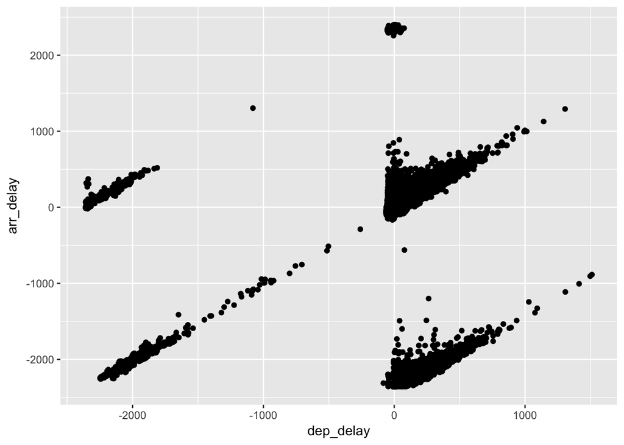

```r
ggplot(flights, aes(x = dep_delay, y = arr_delay)) +
  geom_point()
```

We might want to color the data points by the carrier

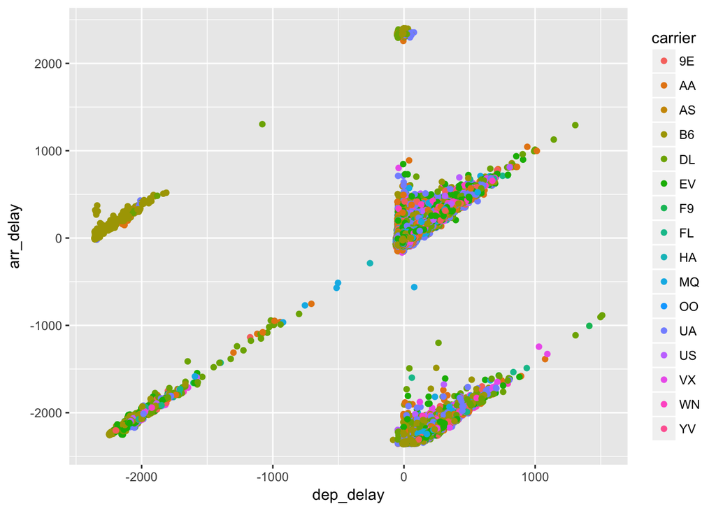

```r
ggplot(flights, aes(x = dep_delay, y = arr_delay, color = carrier)) +
  geom_point()
```

We can even combine plots with data manipulations connected through pipes:

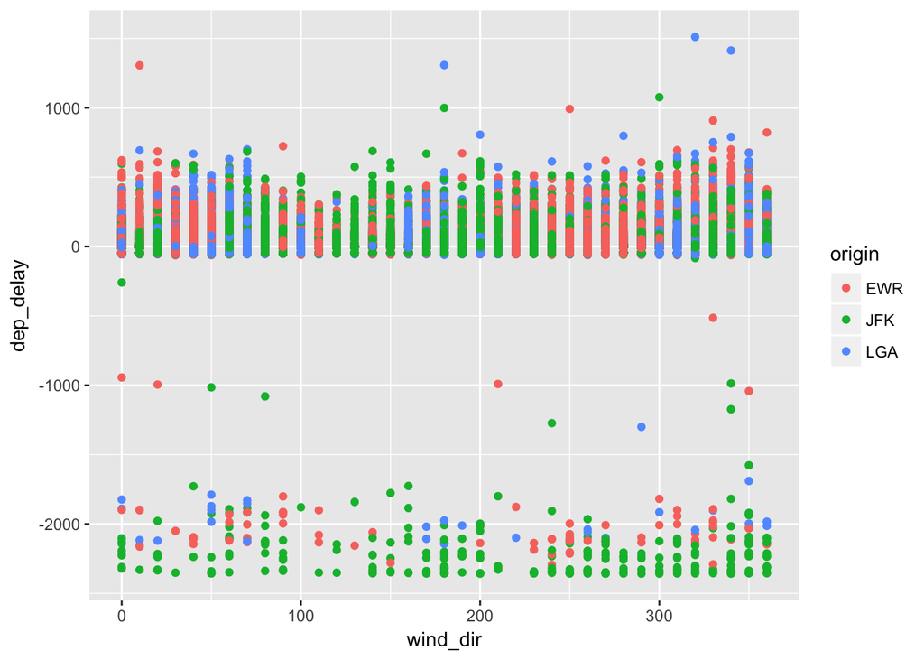

```r
flights %>%
  inner_join(weather) %>%
  ggplot(aes(x = wind_dir,
             y = dep_delay,
             color = origin)) +
  geom_point()
```

This is an interesting plot but hard to understand since the data from the 3 airports are plotted on top of each other. We might want to break those apart by using what is called a facet or `facet_wrap()` in our plot building command. `facet_wrap()` takes as its first argument a one-sided formula that tells it which variable to use to construct the facets. For example,

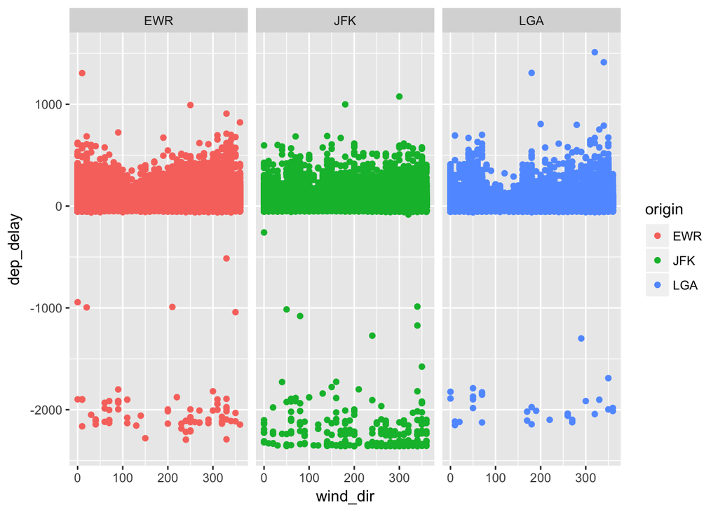

```r
flights %>%
  inner_join(weather) %>%
  ggplot(aes(x = wind_dir,
             y = dep_delay,
             color = origin)) +
  geom_point() +
  facet_wrap(~ origin)
```

We can also do things like putting in a smoother to show with the data:

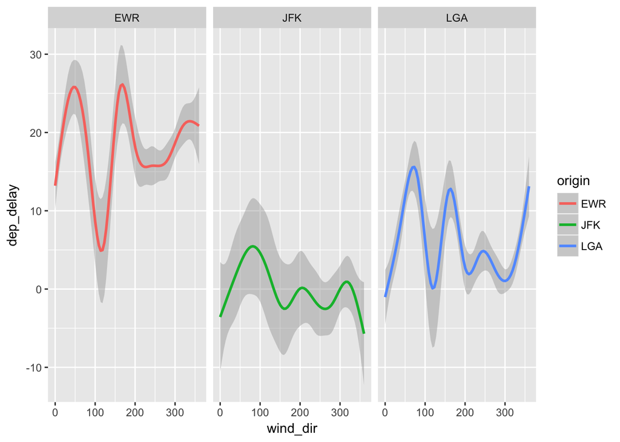

```r
flights %>%
  inner_join(weather) %>%
  ggplot(aes(x = wind_dir,
             y = dep_delay,
             color = origin)) +
  geom_smooth() +
  facet_wrap(~ origin)
```

We didn’t pass the argument `method` in `geom_smooth()` and so it defaulted to using a GAM smoother which is a locally-weighted smoother that performs well and fast on large data sets. For small data sets, it defaults to `loess` which is a similar idea as GAM but slower. You can also tell `geom_smooth()` what type of smoother to use (e.g., `lm` for linear model for a line-of-best-fit).

You might think that the data is describing a circle - 360 and 0 degrees are the same direction - and wouldn’t it be nice if the data was shown with the x variable forming a circle? We can convert the data to be shown in a polar coordinate system instead of an Cartesian system by adding `coord_polar()` to the statement that builds the model:

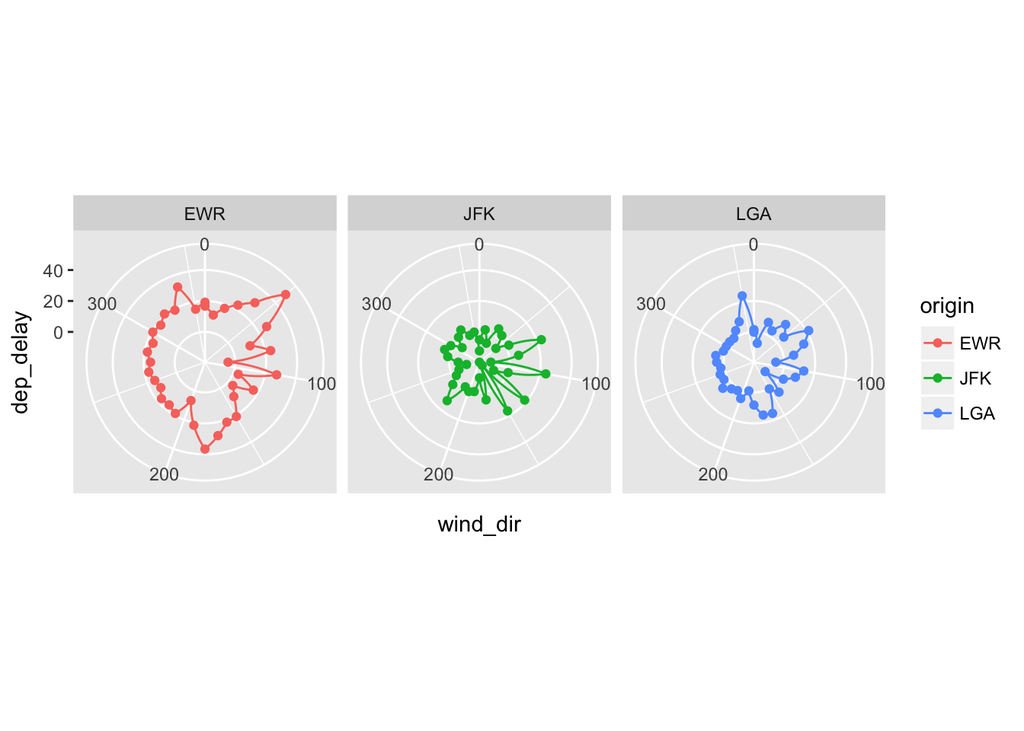

```r
flights %>%
  inner_join(weather) %>%
  group_by(origin, wind_dir = round(wind_dir)) %>%
  summarize(dep_delay = mean(dep_delay, na.rm = TRUE)) %>%
  ggplot(aes(x = wind_dir,
             y = dep_delay,
             color = origin)) +
  geom_point() +
  geom_path() +
  facet_wrap(~ origin) +
  coord_polar()
```

We can take the same graph and improve the labeling or change the theme as well. The `labs()` argument is used to set the labels for the axis of the plot while there are a number of themes built-in such as `theme_bw()` or `theme_minimal()`. Custom themes can be built with the `theme()` function and the package [`ggthemes`](https://cran.r-project.org/web/packages/ggthemes/vignettes/ggthemes.html) provides a variety of themes you might want to use.

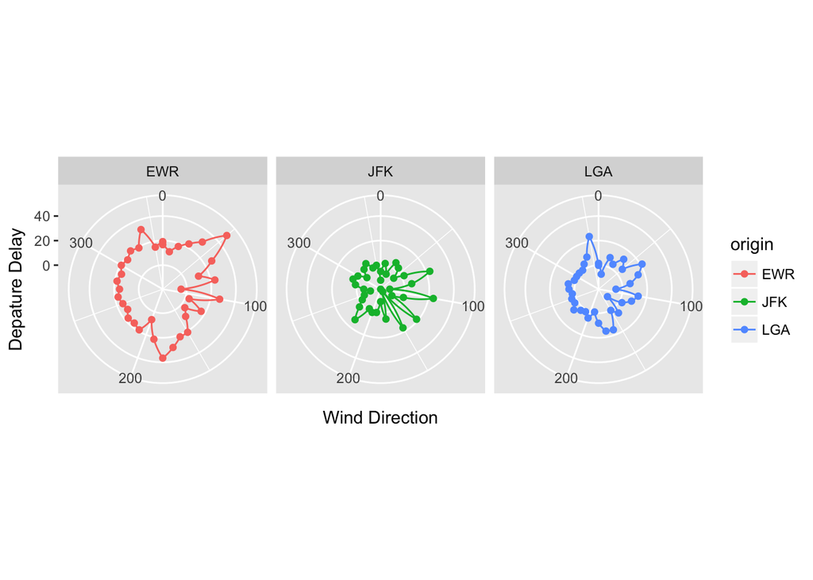

```r
flights %>%
  inner_join(weather) %>%
  group_by(origin, wind_dir = round(wind_dir)) %>%
  summarize(dep_delay = mean(dep_delay, na.rm = TRUE)) %>%
  ggplot(aes(x = wind_dir,
             y = dep_delay,
             color = origin)) +
  geom_point() +
  geom_path() +
  facet_wrap(~ origin) +
  coord_polar() +
  labs(x = "Wind Direction", y = "Depature Delay")
```

You can even generate maps in `ggplot2` but this requires that you install the package `mapproj` as well.

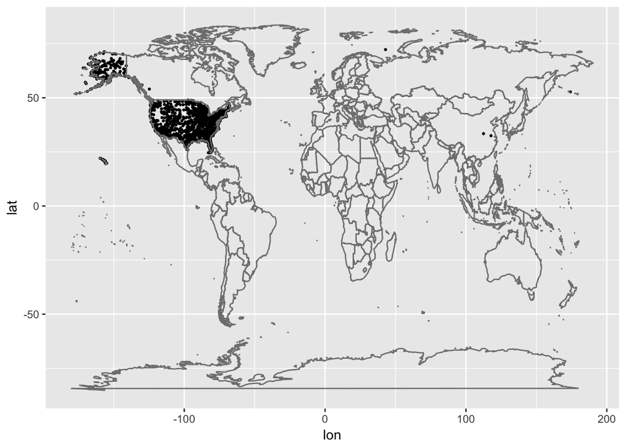

```r
ggplot(airports, aes(x = lon, y = lat)) +
  geom_point(size = 0.5) +
  borders()
```

# Regression

For more information, see the [Model Building Chapter in R for Data Science](http://r4ds.had.co.nz/model-building.html)

Regression is the main way in which we estimate the effect of some variable(s) $X$ on some outcome $y$. You’ve probably heard of linear regression (line of best fit). There are other methods known as generalized linear models (GLM) that are commonly used regression methods as well. These are used when the response variable has special properties - such as being binary (yes/no, disease/no disease) or counts. Aaron will talk about logistic regression next week which is a case of GLM and he will use the `glm()` function. The syntax does not vary according to the desired model in `glm()`, you just change the desired family.

In R, a model is estimated by selecting the function we will use to do the estimation (in this case `glm()`) and then providing a formula that describes the model. Typically, inside a call to `glm()` you will use 2 or 3 arguments. They are

- formula (first) - the specification of the model you want to estimate. A formula is written in the form `<response> ~ <x>` in the most simple case. A more complicated model that includes several possible predictors is written as `<response> ~ <x1> + <x2> + ... + <xk>`. You can include transformations in the formula (e.g., `log` or `sqrt`). R will process the formula and build the model matrix (e.g., it handles construction of dummy variables for you).
- family (second) - the distribution of the response data. You’ll probably either leave this as the default `gaussian()` for classic linear models or `binomial()` for binary response data.
- data (third) - the data set to use to estimate the model

For example, we might want to know how the arrival delay is affected by the departure delay. We would regress the arrival delay in `flights` on the departure delay to decompose the arrival delay into the portion that is caused by departure delays and the portion caused by other factors. The data set we would want to use is `flights`, the model would be `arr_delay ~ dep_delay` and we can leave the family as `guassian()`. The model building step would look like:

```r
model <- glm(arr_delay ~ dep_delay,
             data = flights)
```

If we want to see a summary of the model fit with hypothesis tests, we would use the `summary()` function (`summary(x)` applied to nearly any object in R will produce a summary of `x` that varies based on what `x` is. In this case, `x` is a model and so it provides a summary of the model fit but if `x` was a data.frame/tibble, it would provide a variable-by-variable summary including the min, 1st, 2nd, 3rd quartiles, mean and max.).

```r
summary(model)
```

```
##
## Call:
## glm(formula = arr_delay ~ dep_delay, data = flights)
##
## Deviance Residuals:
##      Min        1Q    Median        3Q       Max
## -2336.16     10.11     26.72     44.84   2431.63
##
## Coefficients:
##               Estimate Std. Error t value Pr(>|t|)
## (Intercept) -31.973253   0.587718  -54.40   <2e-16 ***
## dep_delay     0.131858   0.004037   32.66   <2e-16 ***
## ---
## Signif. codes:  0 '***' 0.001 '**' 0.01 '*' 0.05 '.' 0.1 ' ' 1
##
## (Dispersion parameter for gaussian family taken to be 112933.3)
##
##     Null deviance: 3.7169e+10  on 328062  degrees of freedom
## Residual deviance: 3.7049e+10  on 328061  degrees of freedom
##   (8713 observations deleted due to missingness)
## AIC: 4747873
##
## Number of Fisher Scoring iterations: 2
```

# Functional Programming (Probably Won’t Get to)

For more detail see [R for Data Science Chapter 25](http://r4ds.had.co.nz/many-models.html).

One of the most powerful things about the tidyverse is the ability do construct “list-columns” inside a tibble. There look like and behave like normal columns but instead of containing an atomic value, they contain a tibble. You construct these with the `nest()` command and the nesting is done by the groups of the tibble. For instance, if I wanted to nest the data by airline and airport, I would

```r
nested_flights <- flights %>%
  group_by(carrier, origin) %>%
  nest()
nested_flights
```

```
## # A tibble: 35 x 3
##    carrier origin                   data
##      <chr>  <chr>                 <list>
##  1      UA    EWR <tibble [46,087 x 18]>
##  2      UA    LGA  <tibble [8,044 x 18]>
##  3      AA    JFK <tibble [13,783 x 18]>
##  4      B6    JFK <tibble [42,076 x 18]>
##  5      DL    LGA <tibble [23,067 x 18]>
##  6      B6    EWR  <tibble [6,557 x 18]>
##  7      EV    LGA  <tibble [8,826 x 18]>
##  8      AA    LGA <tibble [15,459 x 18]>
##  9      UA    JFK  <tibble [4,534 x 18]>
## 10      B6    LGA  <tibble [6,002 x 18]>
## # ... with 25 more rows
```

Notice how `carrier` and `origin` are both columns of vectors but the new variable `data` is a tibble. That tibble contains only the rows of data for that row’s `carrier` and `origin` values.

You can interact with that data using the `purrr` package. For instance, if we wanted to fit a model that predicted the probability of a plane leaving late based on the number of flights out, the month, day-of-week, wind speed, hour and flight distance with a different model for each airline and airport we could do something like this:

```r
weather_and_time <- flights %>%
  ungroup() %>%
  inner_join(weather) %>%
  select(carrier, origin,
         dep_delay,
         year, month, day, hour,
         wind_speed, distance)
number_of_flights <- flights %>%
  group_by(origin, year, month, day, hour) %>%
  summarize(number_of_flights_hour = n())


model_data <- inner_join(weather_and_time, number_of_flights) %>%
    mutate(day_of_week = as.factor(lubridate::wday(lubridate::ymd(paste(year, month, day)))),
         month = as.factor(month)) %>%
  select(-year, -day)
model_data
```

```
## # A tibble: 139,029 x 9
##    carrier origin dep_delay  month  hour wind_speed distance
##      <chr>  <chr>     <int> <fctr> <int>      <dbl>    <int>
##  1      DL    LGA       -46      1     6   13.80936      762
##  2      B6    EWR       -45      1     6   10.35702     1065
##  3      EV    LGA       -43      1     6   13.80936      229
##  4      B6    JFK       -43      1     6   12.65858      944
##  5      AA    LGA       -42      1     6   13.80936      733
##  6      B6    JFK       -42      1     6   12.65858     1028
##  7      B6    JFK       -42      1     6   12.65858     1005
##  8      UA    JFK       -42      1     6   12.65858     2475
##  9      UA    EWR       -42      1     6   10.35702     2565
## 10      AA    LGA       -41      1     6   13.80936     1389
## # ... with 139,019 more rows, and 2 more variables:
## #   number_of_flights_hour <int>, day_of_week <fctr>
```

```r
model_data <- model_data %>%
  group_by(carrier, origin) %>%
  nest() %>%
  filter(carrier %in% c("AA", "UA", "DL"))
model_data
```

```
## # A tibble: 9 x 3
##   carrier origin                  data
##     <chr>  <chr>                <list>
## 1      DL    LGA  <tibble [9,752 x 7]>
## 2      AA    LGA  <tibble [6,300 x 7]>
## 3      UA    JFK  <tibble [1,898 x 7]>
## 4      UA    EWR <tibble [19,086 x 7]>
## 5      AA    EWR  <tibble [1,460 x 7]>
## 6      DL    JFK  <tibble [8,133 x 7]>
## 7      DL    EWR  <tibble [1,747 x 7]>
## 8      UA    LGA  <tibble [3,248 x 7]>
## 9      AA    JFK  <tibble [5,870 x 7]>
```

```r
model_data <- model_data %>%
  mutate(model = purrr::map(data, ~ lm(dep_delay ~ ., data = .)))
model_data
```

```
## # A tibble: 9 x 4
##   carrier origin                  data    model
##     <chr>  <chr>                <list>   <list>
## 1      DL    LGA  <tibble [9,752 x 7]> <S3: lm>
## 2      AA    LGA  <tibble [6,300 x 7]> <S3: lm>
## 3      UA    JFK  <tibble [1,898 x 7]> <S3: lm>
## 4      UA    EWR <tibble [19,086 x 7]> <S3: lm>
## 5      AA    EWR  <tibble [1,460 x 7]> <S3: lm>
## 6      DL    JFK  <tibble [8,133 x 7]> <S3: lm>
## 7      DL    EWR  <tibble [1,747 x 7]> <S3: lm>
## 8      UA    LGA  <tibble [3,248 x 7]> <S3: lm>
## 9      AA    JFK  <tibble [5,870 x 7]> <S3: lm>
```

```r
model_data$model[[1]]
```

```
##
## Call:
## lm(formula = dep_delay ~ ., data = .)
##
## Coefficients:
##            (Intercept)                  month2                  month3
##              -65.84141                 6.44342                11.82522
##                month10                 month11                 month12
##              -13.54111                -7.74709                11.09157
##                   hour              wind_speed                distance
##                2.03274                 0.13580                 0.02075
## number_of_flights_hour            day_of_week2            day_of_week3
##                0.84218                -2.94724                 4.03134
##           day_of_week4            day_of_week5            day_of_week6
##                0.80011                 6.33013                 7.62275
##           day_of_week7
##               -0.23268
```

We can use the `broom` package to extract the estimated coefficients of the model and see if the different airlines have different sensitivities to the number of flights out of the airport:

```r
sensitivity_to_congestion <- model_data %>%
  mutate(sens_to_congestion = purrr::map(model,
                                         ~ broom::tidy(.) %>%
                                           as_tibble() %>%
                                           filter(term == "number_of_flights_hour") %>%
                                           select(estimate))) %>%
  select(carrier, origin, sens_to_congestion) %>%
  unnest()
sensitivity_to_congestion
```

```
## # A tibble: 9 x 3
##   carrier origin   estimate
##     <chr>  <chr>      <dbl>
## 1      DL    LGA  0.8421790
## 2      AA    LGA -0.5359629
## 3      UA    JFK  0.2560403
## 4      UA    EWR  0.5894601
## 5      AA    EWR -0.3556103
## 6      DL    JFK  0.8433653
## 7      DL    EWR  0.2371391
## 8      UA    LGA -0.2883230
## 9      AA    JFK  0.1306585
```

And if we return to the `ggplot` section we can visualize this as

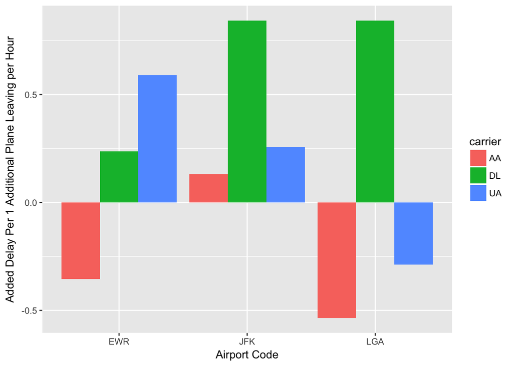

```r
ggplot(sensitivity_to_congestion, aes(x = origin, y = estimate, fill = carrier)) +
  geom_bar(stat = "identity", position = "dodge") +
  labs(x = "Airport Code", y = "Added Delay Per 1 Additional Plane Leaving per Hour")
```

This structure can be helpful when estimating many models that are only slightly different or when doing something like cross-validation. There is an extension to the `dplyr` family called [`multidplyr`](https://github.com/hadley/multidplyr) that divides the data frame/tibble into shards and breaks the work across several threads. This can be useful when you are fitting many models or doing several million rows data manipulations.